# Expansión de la CASEN sobre el CENSO de PERSONAS (Nivel nacional urbano para el 2017)

Y regresión lineal de ingresos medios por zona sobre frecuencias de respuesta a la pregunta: P17 ¿Trabajó por un pago o especie?, cuya correlación (0.8717) resultó ser la más alta con los ingresos expandidos.

VE-CC-AJ

DataIntelligence

date: 02-08-2021

# 1 Resumen

Iniciaremos expandiendo los ingresos promedios (multiplicación del ingreso promedio mensual comunal y los habitantes de la misma comuna) obtenidos de la CASEN 2017 sobre la categoría de respuesta: “Trabajó por un pago o especie” del campo P17 del CENSO de personas del 2017, que fue la categoría de respuesta que más alto correlacionó con los ingresos expandidos, ambos a nivel comunal y ambos a nivel URBANO.

Seguiremos con un análisis sobre todas las zonas Chile comenzando en éste artículo a nivel urbano. En un segundo artículo haremos la publicación a nivel rural.

Como una tercera parte, y ya construída nuestra tabla de trabajo, haremos el análisis por región. Ensayaremos diferentes modelos dentro del análisis de regresión cuya variable independiente será: “frecuencia de población que posee la variable Censal respecto a la zona” y la dependiente: “ingreso expandido por zona por proporción de población zonal respecto al total comunal (**multipob**)”. Lo anterior para elegir el que posea el mayor coeficiente de determinación y así construir una tabla de valores predichos (estimación del ingreso e ingreso estimado por zona).

## 1.1 Variable CENSO

Necesitamos calcular las frecuencias a nivel censal de las respuestas correspondientes a la categoría: “Trabajó por un pago o especie” del campo **P17** del Censo de personas. Recordemos que ésta fué la más alta correlación en relación a los ingresos expandidos [(ver aquí)](https://rpubs.com/dataintelligence/corr_ce_ca_compendio_II).

### 1.1.1 Lectura de la tabla censal de personas

Leemos la tabla Censo 2017 de personas que ya tiene integrada la clave zonal:

```r
tabla_con_clave <-
readRDS("../../../ds_correlaciones_censo_casen/corre_censo_casen_2017/censos_con_clave/censo_personas_con_clave_17")

abc <- head(tabla_con_clave,50)
kbl(abc) %>%
  kable_styling(bootstrap_options = c("striped", "hover")) %>%
  kable_paper() %>%
  scroll_box(width = "100%", height = "300px")
```

| REGION | PROVINCIA | COMUNA | DC | AREA | ZC_LOC | ID_ZONA_LOC | NVIV | NHOGAR | PERSONAN | P07 | P08 | P09 | P10 | P10COMUNA | P10PAIS | P11 | P11COMUNA | P11PAIS | P12 | P12COMUNA | P12PAIS | P12A_LLEGADA | P12A_TRAMO | P13 | P14 | P15 | P15A | P16 | P16A | … |
| --- | --- | --- | --- | --- | --- | --- | --- | --- | --- | --- | --- | --- | --- | --- | --- | --- | --- | --- | --- | --- | --- | --- | --- | --- | --- | --- | --- | --- | --- | --- |
| 15 | 152 | 15202 | 1 | 2 | 6 | 13225 | 1 | 1 | 1 | 1 | 1 | 73 | 1 | 98 | 998 | 3 | 15101 | 998 | 1 | 98 | 998 | 9998 | 98 | 2 | 4 | 6 | 2 | 1 | 2 | … |
| 15 | 152 | 15202 | 1 | 2 | 6 | 13225 | 3 | 1 | 1 | 1 | 1 | 78 | 1 | 98 | 998 | 2 | 98 | 998 | 1 | 98 | 998 | 9998 | 98 | 3 | 98 | 98 | 98 | 1 | 2 | … |
| 15 | 152 | 15202 | 1 | 2 | 6 | 13225 | 3 | 1 | 2 | 2 | 2 | 78 | 1 | 98 | 998 | 2 | 98 | 998 | 1 | 98 | 998 | 9998 | 98 | 3 | 98 | 98 | 98 | 1 | 2 | … |
| 15 | 152 | 15202 | 1 | 2 | 6 | 13225 | 3 | 1 | 3 | 5 | 2 | 52 | 1 | 98 | 998 | 2 | 98 | 998 | 1 | 98 | 998 | 9998 | 98 | 1 | 2 | 5 | 2 | 1 | 2 | … |
| 15 | 152 | 15202 | 1 | 2 | 6 | 13225 | 3 | 1 | 4 | 11 | 1 | 44 | 1 | 98 | 998 | 2 | 98 | 998 | 1 | 98 | 998 | 9998 | 98 | 1 | 3 | 5 | 2 | 1 | 2 | … |
| 15 | 152 | 15202 | 1 | 2 | 6 | 13225 | 9 | 1 | 1 | 1 | 1 | 39 | 1 | 98 | 998 | 2 | 98 | 998 | 1 | 98 | 998 | 9998 | 98 | 2 | 8 | 5 | 1 | 1 | 2 | … |
| 15 | 152 | 15202 | 1 | 2 | 6 | 13225 | 9 | 1 | 2 | 2 | 2 | 35 | 1 | 98 | 998 | 2 | 98 | 998 | 1 | 98 | 998 | 9998 | 98 | 2 | 6 | 5 | 2 | 1 | 2 | … |
| 15 | 152 | 15202 | 1 | 2 | 6 | 13225 | 9 | 1 | 3 | 5 | 1 | 13 | 1 | 98 | 998 | 2 | 98 | 998 | 1 | 98 | 998 | 9998 | 98 | 1 | 7 | 5 | 2 | 1 | 2 | … |
| 15 | 152 | 15202 | 1 | 2 | 6 | 13225 | 9 | 1 | 4 | 5 | 1 | 12 | 1 | 98 | 998 | 2 | 98 | 998 | 1 | 98 | 998 | 9998 | 98 | 1 | 6 | 5 | 2 | 1 | 2 | … |
| 15 | 152 | 15202 | 1 | 2 | 6 | 13225 | 10 | 1 | 1 | 1 | 2 | 65 | 1 | 98 | 998 | 2 | 98 | 998 | 1 | 98 | 998 | 9998 | 98 | 2 | 4 | 5 | 2 | 1 | 2 | … |
| 15 | 152 | 15202 | 1 | 2 | 6 | 13225 | 13 | 1 | 1 | 1 | 1 | 50 | 1 | 98 | 998 | 2 | 98 | 998 | 1 | 98 | 998 | 9998 | 98 | 2 | 5 | 5 | 2 | 1 | 2 | … |
| 15 | 152 | 15202 | 1 | 2 | 6 | 13225 | 13 | 1 | 2 | 4 | 2 | 43 | 1 | 98 | 998 | 2 | 98 | 998 | 1 | 98 | 998 | 9998 | 98 | 2 | 6 | 5 | 2 | 1 | 2 | … |
| 15 | 152 | 15202 | 1 | 2 | 6 | 13225 | 13 | 1 | 3 | 5 | 1 | 15 | 3 | 15201 | 998 | 2 | 98 | 998 | 1 | 98 | 998 | 9998 | 98 | 1 | 1 | 7 | 2 | 1 | 2 | … |
| 15 | 152 | 15202 | 1 | 2 | 6 | 13225 | 16 | 1 | 1 | 1 | 1 | 75 | 1 | 98 | 998 | 2 | 98 | 998 | 1 | 98 | 998 | 9998 | 98 | 3 | 98 | 98 | 98 | 1 | 2 | … |
| 15 | 152 | 15202 | 1 | 2 | 6 | 13225 | 16 | 1 | 2 | 16 | 2 | 58 | 4 | 98 | 68 | 6 | 98 | 998 | 5 | 98 | 998 | 9999 | 1 | 3 | 98 | 98 | 98 | 1 | 2 | … |
| 15 | 152 | 15202 | 1 | 2 | 6 | 13225 | 16 | 1 | 3 | 2 | 2 | 70 | 1 | 98 | 998 | 2 | 98 | 998 | 1 | 98 | 998 | 9998 | 98 | 3 | 98 | 98 | 98 | 1 | 2 | … |
| 15 | 152 | 15202 | 1 | 2 | 6 | 13225 | 17 | 1 | 1 | 1 | 2 | 43 | 2 | 98 | 998 | 2 | 98 | 998 | 1 | 98 | 998 | 9998 | 98 | 2 | 8 | 5 | 1 | 1 | 2 | … |
| 15 | 152 | 15202 | 1 | 2 | 6 | 13225 | 17 | 1 | 2 | 4 | 1 | 55 | 2 | 98 | 998 | 2 | 98 | 998 | 1 | 98 | 998 | 9998 | 98 | 2 | 6 | 5 | 2 | 1 | 2 | … |
| 15 | 152 | 15202 | 1 | 2 | 6 | 13225 | 17 | 1 | 3 | 5 | 2 | 13 | 2 | 98 | 998 | 2 | 98 | 998 | 2 | 15101 | 998 | 9998 | 98 | 1 | 7 | 5 | 2 | 1 | 2 | … |
| 15 | 152 | 15202 | 1 | 2 | 6 | 13225 | 17 | 1 | 4 | 5 | 1 | 8 | 2 | 98 | 998 | 2 | 98 | 998 | 2 | 15101 | 998 | 9998 | 98 | 1 | 2 | 5 | 2 | 1 | 2 | … |
| 15 | 152 | 15202 | 1 | 2 | 6 | 13225 | 17 | 1 | 5 | 15 | 2 | 29 | 2 | 98 | 998 | 4 | 98 | 998 | 3 | 98 | 998 | 2015 | 1 | 2 | 6 | 5 | 2 | 1 | 2 | … |
| 15 | 152 | 15202 | 1 | 2 | 6 | 13225 | 17 | 1 | 6 | 15 | 1 | 4 | 2 | 98 | 998 | 1 | 98 | 998 | 5 | 98 | 998 | 2015 | 1 | 1 | 0 | 1 | 2 | 1 | 2 | … |
| 15 | 152 | 15202 | 1 | 2 | 6 | 13225 | 17 | 1 | 7 | 15 | 2 | 2 | 2 | 98 | 998 | 1 | 98 | 998 | 3 | 98 | 998 | 2015 | 1 | 1 | 0 | 1 | 2 | 1 | 2 | … |
| 15 | 152 | 15202 | 1 | 2 | 6 | 13225 | 17 | 1 | 8 | 15 | 1 | 16 | 2 | 98 | 998 | 6 | 98 | 998 | 1 | 98 | 998 | 9998 | 98 | 2 | 4 | 5 | 2 | 1 | 2 | … |
| 15 | 152 | 15202 | 1 | 2 | 6 | 13225 | 18 | 1 | 1 | 1 | 2 | 74 | 1 | 98 | 998 | 2 | 98 | 998 | 1 | 98 | 998 | 9998 | 98 | 2 | 2 | 5 | 2 | 1 | 2 | … |
| 15 | 152 | 15202 | 1 | 2 | 6 | 13225 | 19 | 1 | 1 | 1 | 1 | 68 | 1 | 98 | 998 | 2 | 98 | 998 | 1 | 98 | 998 | 9998 | 98 | 3 | 98 | 98 | 98 | 1 | 2 | … |
| 15 | 152 | 15202 | 1 | 2 | 6 | 13225 | 20 | 1 | 1 | 1 | 1 | 74 | 1 | 98 | 998 | 3 | 15101 | 998 | 1 | 98 | 998 | 9998 | 98 | 2 | 2 | 5 | 2 | 1 | 2 | … |
| 15 | 152 | 15202 | 1 | 2 | 6 | 13225 | 20 | 1 | 2 | 2 | 2 | 65 | 1 | 98 | 998 | 3 | 997 | 998 | 3 | 98 | 998 | 9999 | 2 | 2 | 2 | 5 | 2 | 1 | 2 | … |
| 15 | 152 | 15202 | 1 | 2 | 6 | 13225 | 25 | 1 | 1 | 1 | 2 | 76 | 1 | 98 | 998 | 2 | 98 | 998 | 1 | 98 | 998 | 9998 | 98 | 3 | 98 | 98 | 98 | 1 | 2 | … |
| 15 | 152 | 15202 | 1 | 2 | 6 | 13225 | 25 | 1 | 2 | 5 | 2 | 36 | 1 | 98 | 998 | 2 | 98 | 998 | 1 | 98 | 998 | 9998 | 98 | 2 | 4 | 8 | 1 | 1 | 2 | … |
| 15 | 152 | 15202 | 1 | 2 | 6 | 13225 | 28 | 1 | 1 | 1 | 2 | 31 | 1 | 98 | 998 | 2 | 98 | 998 | 5 | 98 | 998 | 2007 | 2 | 2 | 5 | 5 | 2 | 1 | 2 | … |
| 15 | 152 | 15202 | 1 | 2 | 6 | 13225 | 28 | 1 | 2 | 4 | 1 | 35 | 1 | 98 | 998 | 2 | 98 | 998 | 5 | 98 | 998 | 2007 | 2 | 2 | 6 | 5 | 2 | 1 | 2 | … |
| 15 | 152 | 15202 | 1 | 2 | 6 | 13225 | 28 | 1 | 3 | 5 | 1 | 11 | 1 | 98 | 998 | 2 | 98 | 998 | 5 | 98 | 998 | 2007 | 2 | 1 | 5 | 5 | 2 | 1 | 2 | … |
| 15 | 152 | 15202 | 1 | 2 | 6 | 13225 | 28 | 1 | 4 | 5 | 1 | 8 | 1 | 98 | 998 | 2 | 98 | 998 | 1 | 98 | 998 | 9998 | 98 | 1 | 2 | 5 | 2 | 1 | 2 | … |
| 15 | 152 | 15202 | 1 | 2 | 6 | 13225 | 28 | 1 | 5 | 15 | 2 | 74 | 1 | 98 | 998 | 2 | 98 | 998 | 1 | 98 | 998 | 9998 | 98 | 2 | 3 | 5 | 2 | 1 | 2 | … |
| 15 | 152 | 15202 | 1 | 2 | 6 | 13225 | 33 | 1 | 1 | 1 | 1 | 41 | 1 | 98 | 998 | 2 | 98 | 998 | 1 | 98 | 998 | 9998 | 98 | 2 | 8 | 5 | 1 | 1 | 2 | … |
| 15 | 152 | 15202 | 1 | 2 | 6 | 13225 | 33 | 1 | 2 | 2 | 2 | 47 | 1 | 98 | 998 | 2 | 98 | 998 | 1 | 98 | 998 | 9998 | 98 | 2 | 8 | 5 | 1 | 1 | 2 | … |
| 15 | 152 | 15202 | 1 | 2 | 6 | 13225 | 33 | 1 | 3 | 14 | 1 | 88 | 1 | 98 | 998 | 2 | 98 | 998 | 1 | 98 | 998 | 9998 | 98 | 3 | 98 | 98 | 98 | 1 | 2 | … |
| 15 | 152 | 15202 | 1 | 2 | 6 | 13225 | 33 | 1 | 4 | 14 | 1 | 65 | 1 | 98 | 998 | 2 | 98 | 998 | 1 | 98 | 998 | 9998 | 98 | 2 | 2 | 5 | 2 | 1 | 2 | … |
| 15 | 152 | 15202 | 1 | 2 | 6 | 13225 | 36 | 1 | 1 | 1 | 2 | 59 | 1 | 98 | 998 | 2 | 98 | 998 | 1 | 98 | 998 | 9998 | 98 | 2 | 2 | 5 | 2 | 1 | 2 | … |
| 15 | 152 | 15202 | 1 | 2 | 6 | 13225 | 36 | 1 | 2 | 2 | 1 | 56 | 1 | 98 | 998 | 99 | 99 | 999 | 1 | 98 | 998 | 9998 | 98 | 2 | 2 | 5 | 2 | 1 | 2 | … |
| 15 | 152 | 15202 | 1 | 2 | 6 | 13225 | 36 | 1 | 3 | 5 | 2 | 36 | 1 | 98 | 998 | 2 | 98 | 998 | 1 | 98 | 998 | 9998 | 98 | 2 | 8 | 5 | 1 | 1 | 2 | … |
| 15 | 152 | 15202 | 1 | 2 | 6 | 13225 | 36 | 1 | 4 | 12 | 2 | 13 | 1 | 98 | 998 | 2 | 98 | 998 | 1 | 98 | 998 | 9998 | 98 | 1 | 7 | 5 | 2 | 1 | 2 | … |
| 15 | 152 | 15202 | 1 | 2 | 6 | 13225 | 36 | 1 | 5 | 12 | 2 | 6 | 1 | 98 | 998 | 2 | 98 | 998 | 1 | 98 | 998 | 9998 | 98 | 1 | 0 | 3 | 1 | 1 | 2 | … |
| 15 | 152 | 15202 | 1 | 2 | 6 | 13225 | 36 | 1 | 6 | 5 | 1 | 24 | 1 | 98 | 998 | 3 | 15101 | 998 | 1 | 98 | 998 | 9998 | 98 | 2 | 4 | 7 | 1 | 1 | 2 | … |
| 15 | 152 | 15202 | 1 | 2 | 6 | 13225 | 36 | 1 | 7 | 11 | 2 | 24 | 1 | 98 | 998 | 3 | 15101 | 998 | 1 | 98 | 998 | 9998 | 98 | 2 | 4 | 7 | 1 | 1 | 2 | … |
| 15 | 152 | 15202 | 1 | 2 | 6 | 13225 | 36 | 1 | 8 | 12 | 1 | 6 | 1 | 98 | 998 | 2 | 98 | 998 | 2 | 15101 | 998 | 9998 | 98 | 1 | 0 | 3 | 1 | 1 | 2 | … |
| 15 | 152 | 15202 | 1 | 2 | 6 | 13225 | 36 | 1 | 9 | 12 | 2 | 1 | 1 | 98 | 998 | 1 | 98 | 998 | 2 | 15101 | 998 | 9998 | 98 | 3 | 98 | 98 | 98 | 1 | 2 | … |
| 15 | 152 | 15202 | 1 | 2 | 6 | 13225 | 38 | 1 | 1 | 1 | 1 | 19 | 1 | 98 | 998 | 3 | 15101 | 998 | 2 | 15101 | 998 | 9998 | 98 | 1 | 1 | 8 | 2 | 1 | 2 | … |
| 15 | 152 | 15202 | 1 | 2 | 6 | 13225 | 39 | 1 | 1 | 1 | 1 | 21 | 1 | 98 | 998 | 2 | 98 | 998 | 1 | 98 | 998 | 9998 | 98 | 2 | 1 | 7 | 2 | 1 | 2 | … |

Cuantas personas hay en Chile?

```r
length(tabla_con_clave$clave)
```

```
## [1] 17574003
```

Cuántas **zonas** hay en Chile?

```r
length(unique(tabla_con_clave$clave))
```

```
## [1] 15500
```

### 1.1.2 Filtro a nivel urbano:

```r
tabla_con_clave_u <- filter(tabla_con_clave, tabla_con_clave$AREA ==1)
```

Cuantas personas hay en Chile urbanas?

```r
length(tabla_con_clave_u$clave)
```

```
## [1] 15424263
```

Cuantas **zonas** hay en el nivel urbano?

```r
length(unique(tabla_con_clave_u$clave))
```

```
## [1] 5169
```

### 1.1.3 Cálculo de respuestas censales

Obtenemos las respuestas a la pregunta P17 por zona eliminando los campos innecesarios. Despleguemos los primeros 1000 registros:

```r
tabla_con_clave_f <- tabla_con_clave_u[,-c(1,2,4:31,33:48),drop=F]
abc <- head(tabla_con_clave_f,1000)
kbl(abc) %>%
  kable_styling(bootstrap_options = c("striped", "hover")) %>%
  kable_paper() %>%
  scroll_box(width = "100%", height = "300px")
```

| COMUNA | P17 | clave |
| --- | --- | --- |
| 15201 | 1 | 15201011001 |
| 15201 | 1 | 15201011001 |
| 15201 | 1 | 15201011001 |
| 15201 | 1 | 15201011001 |
| 15201 | 1 | 15201011001 |
| 15201 | 3 | 15201011001 |
| 15201 | 5 | 15201011001 |
| 15201 | 98 | 15201011001 |
| 15201 | 1 | 15201011001 |
| 15201 | 1 | 15201011001 |
| 15201 | 1 | 15201011001 |
| 15201 | 6 | 15201011001 |
| 15201 | 1 | 15201011001 |
| 15201 | 8 | 15201011001 |
| 15201 | 6 | 15201011001 |
| 15201 | 1 | 15201011001 |
| 15201 | 1 | 15201011001 |
| 15201 | 1 | 15201011001 |
| 15201 | 99 | 15201011001 |
| 15201 | 99 | 15201011001 |
| 15201 | 1 | 15201011001 |
| 15201 | 1 | 15201011001 |
| 15201 | 1 | 15201011001 |
| 15201 | 1 | 15201011001 |
| 15201 | 6 | 15201011001 |
| 15201 | 1 | 15201011001 |
| 15201 | 98 | 15201011001 |
| 15201 | 98 | 15201011001 |
| 15201 | 3 | 15201011001 |
| 15201 | 98 | 15201011001 |

[output cut: 970 more lines]

```r
nrow(tabla_con_clave_f)
```

```
## [1] 15424263
```

Vemos que el número total de registros coincide con el total de personas urbanas.

Modifiquemos la tabla para poder trabajarla un poco mejor:

1. Agregamos un cero a los códigos comunales de cuatro dígitos.
2. Renombramos la columna clave por código.

```r
codigos <- tabla_con_clave_f$COMUNA
rango <- seq(1:nrow(tabla_con_clave_f))
cadena <- paste("0",codigos[rango], sep = "")
cadena <- substr(cadena,(nchar(cadena)[rango])-(4),6)
codigos <- as.data.frame(codigos)
cadena <- as.data.frame(cadena)
comuna_corr <- cbind(tabla_con_clave_f,cadena)
comuna_corr <- comuna_corr[,-c(1),drop=FALSE]
names(comuna_corr)[3] <- "código"

abc <- head(comuna_corr,50)
kbl(abc) %>%
  kable_styling(bootstrap_options = c("striped", "hover")) %>%
  kable_paper() %>%
  scroll_box(width = "100%", height = "300px")
```

| P17 | clave | código |
| --- | --- | --- |
| 1 | 15201011001 | 15201 |
| 1 | 15201011001 | 15201 |
| 1 | 15201011001 | 15201 |
| 1 | 15201011001 | 15201 |
| 1 | 15201011001 | 15201 |
| 3 | 15201011001 | 15201 |
| 5 | 15201011001 | 15201 |
| 98 | 15201011001 | 15201 |
| 1 | 15201011001 | 15201 |
| 1 | 15201011001 | 15201 |
| 1 | 15201011001 | 15201 |
| 6 | 15201011001 | 15201 |
| 1 | 15201011001 | 15201 |
| 8 | 15201011001 | 15201 |
| 6 | 15201011001 | 15201 |
| 1 | 15201011001 | 15201 |
| 1 | 15201011001 | 15201 |
| 1 | 15201011001 | 15201 |
| 99 | 15201011001 | 15201 |
| 99 | 15201011001 | 15201 |
| 1 | 15201011001 | 15201 |
| 1 | 15201011001 | 15201 |
| 1 | 15201011001 | 15201 |
| 1 | 15201011001 | 15201 |
| 6 | 15201011001 | 15201 |
| 1 | 15201011001 | 15201 |
| 98 | 15201011001 | 15201 |
| 98 | 15201011001 | 15201 |
| 3 | 15201011001 | 15201 |
| 98 | 15201011001 | 15201 |
| 98 | 15201011001 | 15201 |
| 1 | 15201011001 | 15201 |
| 1 | 15201011001 | 15201 |
| 1 | 15201011001 | 15201 |
| 1 | 15201011001 | 15201 |
| 1 | 15201011001 | 15201 |
| 5 | 15201011001 | 15201 |
| 5 | 15201011001 | 15201 |
| 98 | 15201011001 | 15201 |
| 98 | 15201011001 | 15201 |
| 1 | 15201011001 | 15201 |
| 3 | 15201011001 | 15201 |
| 1 | 15201011001 | 15201 |
| 1 | 15201011001 | 15201 |
| 1 | 15201011001 | 15201 |
| 1 | 15201011001 | 15201 |
| 1 | 15201011001 | 15201 |
| 1 | 15201011001 | 15201 |
| 1 | 15201011001 | 15201 |
| 1 | 15201011001 | 15201 |

```r
tabla_con_clave_f <- comuna_corr
```

Obtenemos la cuenta de las respuestas 1:

```r
claves_con_1 <- filter(tabla_con_clave_f, tabla_con_clave_f$P17 == 1)
head(claves_con_1,10)
```

```
##    P17       clave código
## 1    1 15201011001  15201
## 2    1 15201011001  15201
## 3    1 15201011001  15201
## 4    1 15201011001  15201
## 5    1 15201011001  15201
## 6    1 15201011001  15201
## 7    1 15201011001  15201
## 8    1 15201011001  15201
## 9    1 15201011001  15201
## 10   1 15201011001  15201
```

#### 1.1.3.1 Tabla de contingencia:

```r
con4 <- xtabs(~P17+clave, data=claves_con_1)
con4 <- as.data.frame(con4)

abc <- head(con4,50)
kbl(abc) %>%
  kable_styling(bootstrap_options = c("striped", "hover")) %>%
  kable_paper() %>%
  scroll_box(width = "100%", height = "300px")
```

| P17 | clave | Freq |
| --- | --- | --- |
| 1 | 10101011001 | 320 |
| 1 | 10101011002 | 1309 |
| 1 | 10101021001 | 1828 |
| 1 | 10101021002 | 581 |
| 1 | 10101021003 | 1050 |
| 1 | 10101021004 | 1457 |
| 1 | 10101021005 | 1165 |
| 1 | 10101031001 | 2012 |
| 1 | 10101031002 | 2166 |
| 1 | 10101031003 | 1663 |
| 1 | 10101031004 | 1172 |
| 1 | 10101031005 | 2657 |
| 1 | 10101031006 | 1233 |
| 1 | 10101031007 | 1038 |
| 1 | 10101031008 | 1616 |
| 1 | 10101031009 | 1995 |
| 1 | 10101031010 | 1531 |
| 1 | 10101031011 | 1232 |
| 1 | 10101031012 | 837 |
| 1 | 10101031013 | 1642 |
| 1 | 10101031014 | 1030 |
| 1 | 10101031015 | 873 |
| 1 | 10101031016 | 1285 |
| 1 | 10101031017 | 1457 |
| 1 | 10101041001 | 1843 |
| 1 | 10101041002 | 895 |
| 1 | 10101041003 | 2559 |
| 1 | 10101051001 | 1148 |
| 1 | 10101051002 | 814 |
| 1 | 10101051003 | 1329 |
| 1 | 10101051004 | 1712 |
| 1 | 10101061001 | 3383 |
| 1 | 10101061002 | 1254 |
| 1 | 10101061003 | 1559 |
| 1 | 10101061004 | 1184 |
| 1 | 10101061005 | 1216 |
| 1 | 10101061006 | 1991 |
| 1 | 10101061007 | 340 |
| 1 | 10101061008 | 1008 |
| 1 | 10101061009 | 68 |
| 1 | 10101061010 | 610 |
| 1 | 10101071001 | 909 |
| 1 | 10101071002 | 1583 |
| 1 | 10101071003 | 1915 |
| 1 | 10101071004 | 1419 |
| 1 | 10101071005 | 1186 |
| 1 | 10101071006 | 1741 |
| 1 | 10101071007 | 987 |
| 1 | 10101071008 | 2104 |
| 1 | 10101071009 | 1509 |

```r
nrow(con4)
```

```
## [1] 5165
```

No perdemos ni una zona a excepción de 4. Más adelante veremos porqué.

A la tabla de frecuencias por zona le añadimos el campo comunal:

```r
trabajo_001 = merge( x = con4, y =claves_con_1, by = "clave", all.x = TRUE)
head(trabajo_001,10)
```

```
##          clave P17.x Freq P17.y código
## 1  10101011001     1  320     1  10101
## 2  10101011001     1  320     1  10101
## 3  10101011001     1  320     1  10101
## 4  10101011001     1  320     1  10101
## 5  10101011001     1  320     1  10101
## 6  10101011001     1  320     1  10101
## 7  10101011001     1  320     1  10101
## 8  10101011001     1  320     1  10101
## 9  10101011001     1  320     1  10101
## 10 10101011001     1  320     1  10101
```

Eliminamos los registros repetidos y renombramos COMUNA como código:

```r
trabajo003 <- unique(trabajo_001)
trabajo003 <- trabajo003[,-c(2,4)]
# trabajo003$código <- as.numeric(trabajo003$código)
head(trabajo003,10)
```

```
##             clave Freq código
## 1     10101011001  320  10101
## 321   10101011002 1309  10101
## 1630  10101021001 1828  10101
## 3458  10101021002  581  10101
## 4039  10101021003 1050  10101
## 5089  10101021004 1457  10101
## 6546  10101021005 1165  10101
## 7711  10101031001 2012  10101
## 9723  10101031002 2166  10101
## 11889 10101031003 1663  10101
```

```r
nrow(trabajo003)
```

```
## [1] 5165
```

Calculamos los ingresos expandidos a nivel urbano:

```r
x <- import("../../../../archivos_grandes/Microdato_Censo2017-Personas.csv")
casen_2017 <- readRDS(file = "../../../../archivos_grandes/casen_2017_c.rds")

casen_2017_u <- filter(casen_2017, casen_2017$zona == "Urbano")
casen_2017_u <- casen_2017_u[!is.na(casen_2017_u$ytotcor),]
Q <- quantile(casen_2017_u$ytotcor, probs=c(.25, .75), na.rm = FALSE)
iqr <- IQR(casen_2017_u$ytotcor)
casen_2017_sin_o <- subset(casen_2017_u, casen_2017_u$ytotcor >
                                 (Q[1] - 1.5*iqr) &
                                 casen_2017_u$ytotcor < (Q[2]+1.5*iqr))
casen_2017_sin_o <- data.frame(lapply(casen_2017_sin_o, as.character),
                               stringsAsFactors=FALSE)

b <-  as.numeric(casen_2017_sin_o$ytotcor)
a <- casen_2017_sin_o$comuna
promedios_grupales <-aggregate(b, by=list(a), FUN = mean , na.rm=TRUE )
names(promedios_grupales)[1] <- "comuna"
names(promedios_grupales)[2] <- "promedio_i"
promedios_grupales$año <- "2017"
codigos_comunales <- readRDS(file = "../../../../archivos_grandes/codigos_comunales_2011-2017.rds")
names(codigos_comunales)[1] <- "código"
names(codigos_comunales)[2] <- "comuna"
df_2017 = merge( promedios_grupales, codigos_comunales,
                 by = "comuna",
                 all.x = TRUE)

my_summary_data <- x %>%
    group_by(x$COMUNA) %>%
    summarise(Count = n())
names(my_summary_data)[1] <- "comuna"
names(my_summary_data)[2] <- "personas"
# recogemos el campo Comuna:
codigos <- my_summary_data$comuna
# construimos una secuencia llamada rango del 1 al total de filas del
# dataset:
rango <- seq(1:nrow(my_summary_data))
# Creamos un string que agrega un cero a todos los registros:
cadena <- paste("0",codigos[rango], sep = "")
# El string cadena tiene o 5 o 6 digitos, los cuales siempre deben ser
# siempre 5
# agregandole un cero al inicio de los que tienen 4.
# Para ello extraemos un substring de la cadena sobre todas las filas
#(rangos)
# comenzando desde el primero o el segundo y llegando siempre al 6.
cadena <- substr(cadena,(nchar(cadena)[rango])-(4),6)
codigos <- as.data.frame(codigos)
cadena <- as.data.frame(cadena)
comuna_corr <- cbind(my_summary_data,cadena)
names(comuna_corr)[3] <- "código"
comuna_corr <- comuna_corr[,-c(1),drop=FALSE]
df_2017_2 = merge( comuna_corr, df_2017, by = "código", all.x = TRUE)
df_2017_2$ingresos_expandidos <- df_2017_2$personas*df_2017_2$promedio_i
df_2017_2  <- na.omit(df_2017_2)
```

Veamos los primeros 10 registros:

```r
head(df_2017_2,10)
```

```
##    código personas               comuna promedio_i  año ingresos_expandidos
## 1   01101   191468              Iquique   375676.9 2017         71930106513
## 2   01107   108375        Alto Hospicio   311571.7 2017         33766585496
## 3   01401    15711         Pozo Almonte   316138.5 2017          4966851883
## 7   01405     9296                 Pica   330061.1 2017          3068247619
## 8   02101   361873          Antofagasta   368221.4 2017        133249367039
## 9   02102    13467           Mejillones   369770.7 2017          4979702302
## 11  02104    13317               Taltal   383666.2 2017          5109282942
## 12  02201   165731               Calama   434325.1 2017         71981127235
## 14  02203    10996 San Pedro de Atacama   442861.0 2017          4869699464
## 15  02301    25186            Tocopilla   286187.2 2017          7207910819
```

Guardemos como rds:

```r
saveRDS(df_2017_2, "Ingresos_expandidos_urbano_17.rds")
```

De cuántas comunas disponemos del valor del ingreso promedio?

```r
nrow(df_2017_2)
```

```
## [1] 312
```

```r
#df_2017_2$código <- as.numeric(df_2017_2$código)
head(df_2017_2,10)
```

```
##    código personas               comuna promedio_i  año ingresos_expandidos
## 1   01101   191468              Iquique   375676.9 2017         71930106513
## 2   01107   108375        Alto Hospicio   311571.7 2017         33766585496
## 3   01401    15711         Pozo Almonte   316138.5 2017          4966851883
## 7   01405     9296                 Pica   330061.1 2017          3068247619
## 8   02101   361873          Antofagasta   368221.4 2017        133249367039
## 9   02102    13467           Mejillones   369770.7 2017          4979702302
## 11  02104    13317               Taltal   383666.2 2017          5109282942
## 12  02201   165731               Calama   434325.1 2017         71981127235
## 14  02203    10996 San Pedro de Atacama   442861.0 2017          4869699464
## 15  02301    25186            Tocopilla   286187.2 2017          7207910819
```

Unimos nuestra tabla de frecuencias por zona con la de ingresos expandidos:

```r
comunas_censo_casen_666 = merge( x = trabajo003, y = df_2017_2, by = "código", all.x = TRUE)
head(comunas_censo_casen_666,10)
```

```
##    código      clave Freq personas  comuna promedio_i  año ingresos_expandidos
## 1   01101 1101011001 1255   191468 Iquique   375676.9 2017         71930106513
## 2   01101 1101011002  621   191468 Iquique   375676.9 2017         71930106513
## 3   01101 1101041001  713   191468 Iquique   375676.9 2017         71930106513
## 4   01101 1101041002 1084   191468 Iquique   375676.9 2017         71930106513
## 5   01101 1101041003 1691   191468 Iquique   375676.9 2017         71930106513
## 6   01101 1101021005 1927   191468 Iquique   375676.9 2017         71930106513
## 7   01101 1101041005 1840   191468 Iquique   375676.9 2017         71930106513
## 8   01101 1101041006 1102   191468 Iquique   375676.9 2017         71930106513
## 9   01101 1101051001 1515   191468 Iquique   375676.9 2017         71930106513
## 10  01101 1101041004 2403   191468 Iquique   375676.9 2017         71930106513
```

Cuantas zonas tenemos?

```r
nrow(comunas_censo_casen_666)
```

```
## [1] 5165
```

```r
tabla_de_prop_pob <- readRDS("../../../../archivos_grandes/tabla_de_prop_pob.rds")
names(tabla_de_prop_pob)[1]  <- "clave"
head(tabla_de_prop_pob,10)
```

```
##         clave Freq            p código
## 1  1101011001 2491 0.0130100069  01101
## 2  1101011002 1475 0.0077036372  01101
## 3  1101021001 1003 0.0052384733  01101
## 4  1101021002   54 0.0002820315  01101
## 5  1101021003 2895 0.0151200201  01101
## 6  1101021004 2398 0.0125242860  01101
## 7  1101021005 4525 0.0236331920  01101
## 8  1101031001 2725 0.0142321432  01101
## 9  1101031002 3554 0.0185618485  01101
## 10 1101031003 5246 0.0273988343  01101
```

```r
nrow(tabla_de_prop_pob)
```

```
## [1] 15500
```

```r
comunas_censo_casen_6666 = merge( x = comunas_censo_casen_666, y = tabla_de_prop_pob, by = "clave", all.x = TRUE)
```

```r
nrow(comunas_censo_casen_6666)
```

```
## [1] 5165
```

```r
head(comunas_censo_casen_6666,10)
```

```
##          clave código.x Freq.x personas       comuna promedio_i  año
## 1  10101011001    10101    320   245902 Puerto Montt   304409.6 2017
## 2  10101011002    10101   1309   245902 Puerto Montt   304409.6 2017
## 3  10101021001    10101   1828   245902 Puerto Montt   304409.6 2017
## 4  10101021002    10101    581   245902 Puerto Montt   304409.6 2017
## 5  10101021003    10101   1050   245902 Puerto Montt   304409.6 2017
## 6  10101021004    10101   1457   245902 Puerto Montt   304409.6 2017
## 7  10101021005    10101   1165   245902 Puerto Montt   304409.6 2017
## 8  10101031001    10101   2012   245902 Puerto Montt   304409.6 2017
## 9  10101031002    10101   2166   245902 Puerto Montt   304409.6 2017
## 10 10101031003    10101   1663   245902 Puerto Montt   304409.6 2017
##    ingresos_expandidos Freq.y           p código.y
## 1          74854925754    584 0.002374930    10101
## 2          74854925754   2941 0.011960049    10101
## 3          74854925754   3953 0.016075510    10101
## 4          74854925754   1107 0.004501793    10101
## 5          74854925754   2294 0.009328920    10101
## 6          74854925754   3391 0.013790046    10101
## 7          74854925754   2564 0.010426918    10101
## 8          74854925754   4530 0.018421973    10101
## 9          74854925754   4740 0.019275972    10101
## 10         74854925754   4107 0.016701776    10101
```

```r
comunas_censo_casen_6666$multipob <- comunas_censo_casen_6666$ingresos_expandidos*comunas_censo_casen_6666$p
```

```r
head(comunas_censo_casen_6666,10)
```

```
##          clave código.x Freq.x personas       comuna promedio_i  año
## 1  10101011001    10101    320   245902 Puerto Montt   304409.6 2017
## 2  10101011002    10101   1309   245902 Puerto Montt   304409.6 2017
## 3  10101021001    10101   1828   245902 Puerto Montt   304409.6 2017
## 4  10101021002    10101    581   245902 Puerto Montt   304409.6 2017
## 5  10101021003    10101   1050   245902 Puerto Montt   304409.6 2017
## 6  10101021004    10101   1457   245902 Puerto Montt   304409.6 2017
## 7  10101021005    10101   1165   245902 Puerto Montt   304409.6 2017
## 8  10101031001    10101   2012   245902 Puerto Montt   304409.6 2017
## 9  10101031002    10101   2166   245902 Puerto Montt   304409.6 2017
## 10 10101031003    10101   1663   245902 Puerto Montt   304409.6 2017
##    ingresos_expandidos Freq.y           p código.y   multipob
## 1          74854925754    584 0.002374930    10101  177775198
## 2          74854925754   2941 0.011960049    10101  895268589
## 3          74854925754   3953 0.016075510    10101 1203331089
## 4          74854925754   1107 0.004501793    10101  336981411
## 5          74854925754   2294 0.009328920    10101  698315588
## 6          74854925754   3391 0.013790046    10101 1032252903
## 7          74854925754   2564 0.010426918    10101  780506176
## 8          74854925754   4530 0.018421973    10101 1378975420
## 9          74854925754   4740 0.019275972    10101 1442901433
## 10         74854925754   4107 0.016701776    10101 1250210165
```

```r
saveRDS(comunas_censo_casen_6666, "tabla_de_trabajo_2017_urbana.rds")
write_xlsx(comunas_censo_casen_6666, "tabla_de_trabajo_2017_urbana.xlsx")
```

# 2 Desaparecen 4 zonas

Porque no tienen categoría de respuesta 1 a la pregunta P17

```r
tabla_original <-
readRDS("../../../ds_correlaciones_censo_casen/corre_censo_casen_2017/censos_con_clave/censo_personas_con_clave_17")
tabla_de_trabajo <- readRDS("tabla_de_trabajo_2017_urbana.rds")
```

```r
tabla_con_clave_u <- filter(tabla_original , tabla_original $AREA ==1)
unicos_001 <- unique(tabla_con_clave_u$clave)
length(unicos_001)
```

```
## [1] 5169
```

```r
unicos_002 <- tabla_de_trabajo$clave
length(unicos_002)
```

```
## [1] 5165
```

Identifiquemos los que fueron excluídos:

```r
ddd <- setdiff(unicos_001 ,unicos_002)
ttt <- unique(ddd)
ttt
```

```
## [1] "9113991999"  "16303991999" "7303991999"  "6204991999"
```

```r
#9113991999

tabla_original_1 <- filter(tabla_original, tabla_original$clave == "9113991999")
tabla_original_1
```

```
##   REGION PROVINCIA COMUNA DC AREA ZC_LOC ID_ZONA_LOC NVIV NHOGAR PERSONAN P07
## 1      9        91   9113 99    1    999         232    1      1        1   1
## 2      9        91   9113 99    1    999         232    1      1        2   5
## 3      9        91   9113 99    1    999         232    1      1        3   5
##   P08 P09 P10 P10COMUNA P10PAIS P11 P11COMUNA P11PAIS P12 P12COMUNA P12PAIS
## 1   2  39   1        98     998   2        98     998   1        98     998
## 2   1  12   1        98     998   2        98     998   1        98     998
## 3   2   7   1        98     998   2        98     998   1        98     998
##   P12A_LLEGADA P12A_TRAMO P13 P14 P15 P15A P16 P16A P16A_OTRO P17 P18 P19 P20
## 1         9998         98   2   4   7    1   2   98        98   6  98   2   2
## 2         9998         98   1   6   5    2   2   98        98  98  98  98  98
## 3         9998         98   1   1   5    2   2   98        98  98  98  98  98
##   P21M P21A P10PAIS_GRUPO P11PAIS_GRUPO P12PAIS_GRUPO ESCOLARIDAD P16A_GRUPO
## 1   10 2009           998           998           998          12         98
## 2   98 9998           998           998           998           6         98
## 3   98 9998           998           998           998           1         98
##   REGION_15R PROVINCIA_15R COMUNA_15R P10COMUNA_15R P11COMUNA_15R P12COMUNA_15R
## 1          9            91       9113            98            98            98
## 2          9            91       9113            98            98            98
## 3          9            91       9113            98            98            98
##        clave
## 1 9113991999
## 2 9113991999
## 3 9113991999
```

Hay solamente 4 zonas que no poseen el valor 1 de respuesta a la pregunta P17.

## 2.1 Diagrama de dispersión loess

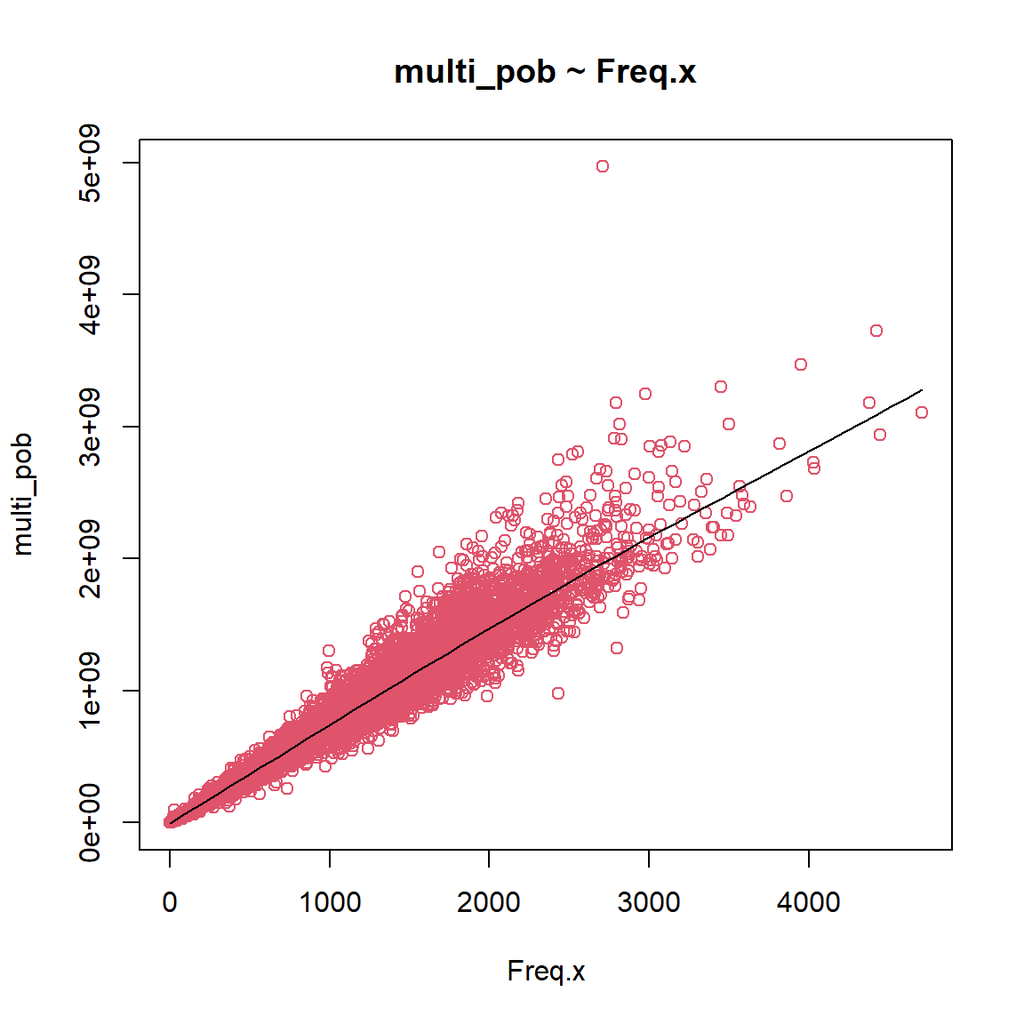

```r
scatter.smooth(x=comunas_censo_casen_6666$Freq.x, y=comunas_censo_casen_6666$multipob, main="multi_pob ~ Freq.x",
     xlab = "Freq.x",
     ylab = "multi_pob",
           col = 2)
```

# 3 Análisis de regresión

Aplicaremos un análisis de regresión donde:

$$Y(dependiente) = ingreso \ expandido \ por \ zona \ (multi\_pob)$$

$$X(independiente) = frecuencia \ de \ población \ que \ posee \ la \ variable \ Censal \ respecto \ a \ la \ zona \ (Freq.x)$$

## 3.1 Outliers

Hemos demostrado en el punto 5.7.2 de [aquí](https://rpubs.com/dataintelligence/expansion_viviendas_001) que la exclusión de ouliers no genera ninguna mejora en el modelo de regresión.

## 3.2 Modelo lineal

Aplicaremos un análisis de regresión lineal del ingreso expandido por zona sobre las frecuencias de respuestas zonales.

```r
linearMod <- lm( multipob~(Freq.x) , data=tabla_de_trabajo)
summary(linearMod)
```

```
##
## Call:
## lm(formula = multipob ~ (Freq.x), data = tabla_de_trabajo)
##
## Residuals:
##        Min         1Q     Median         3Q        Max
## -850547865  -78144039   -6002220   58511371 2933901395
##
## Coefficients:
##             Estimate Std. Error t value Pr(>|t|)
## (Intercept) -3897469    4656177  -0.837    0.403
## Freq.x        753444       3165 238.083   <2e-16 ***
## ---
## Signif. codes:  0 '***' 0.001 '**' 0.01 '*' 0.05 '.' 0.1 ' ' 1
##
## Residual standard error: 162300000 on 5143 degrees of freedom
##   (20 observations deleted due to missingness)
## Multiple R-squared:  0.9168, Adjusted R-squared:  0.9168
## F-statistic: 5.668e+04 on 1 and 5143 DF,  p-value: < 2.2e-16
```

## 3.3 Gráfica de la recta de regresión lineal

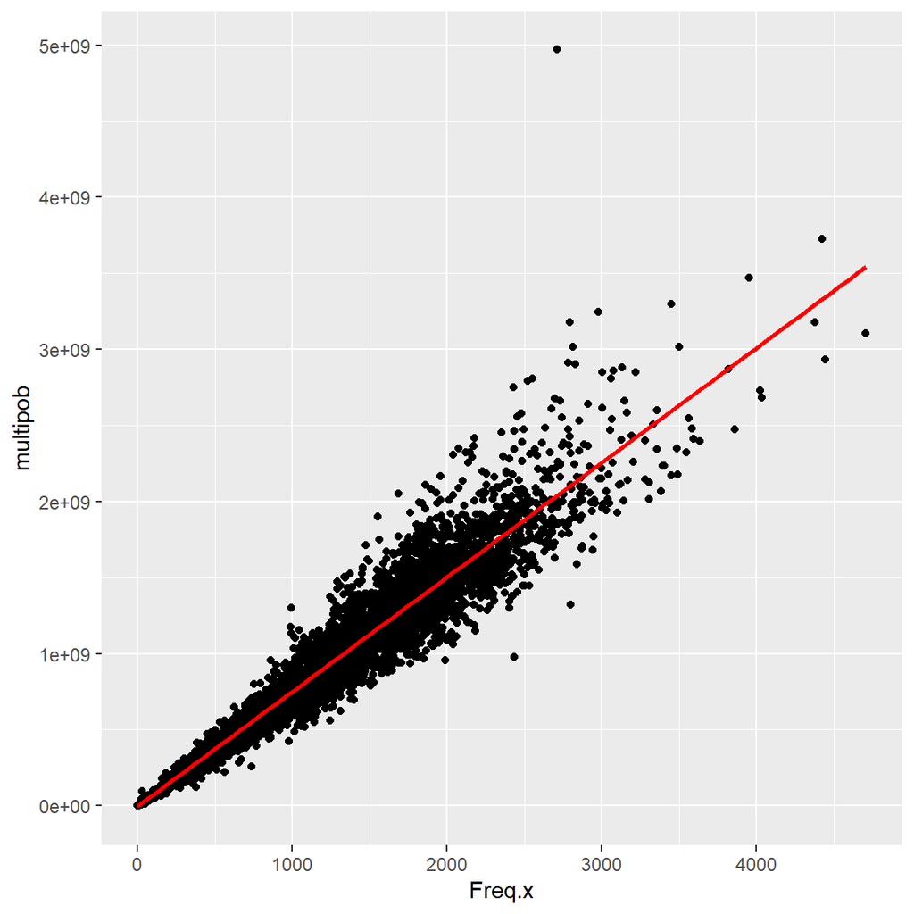

```r
ggplot(tabla_de_trabajo, aes(x = Freq.x , y = multipob)) +
  geom_point() +
  stat_smooth(method = "lm", col = "red")
```

Si bien obtenemos nuestro modelo lineal da cuenta del 0.9168 de la variabilidad de los datos de respuesta en torno a su media, modelos alternativos pueden ofrecernos una explicación de la variable dependiente aún mayor.

# 4 Modelos alternativos

```r
### 8.1 Modelo cuadrático
linearMod <- lm( multipob~(Freq.x^2) , data=tabla_de_trabajo)
datos <- summary(linearMod)
dato <- datos$adj.r.squared
modelo <- "cuadrático"
sintaxis <- "linearMod <- lm( multi_pob~(Freq.x^2) , data=h_y_m_comuna_corr_01)"
modelos1 <- cbind(modelo,dato,sintaxis)

### 8.2 Modelo cúbico
linearMod <- lm( multipob~(Freq.x^3) , data=tabla_de_trabajo)
datos <- summary(linearMod)
dato <- datos$adj.r.squared
modelo <- "cúbico"
sintaxis <- "linearMod <- lm( multi_pob~(Freq.x^3) , data=h_y_m_comuna_corr_01)"
modelos2 <- cbind(modelo,dato,sintaxis)

### 8.3 Modelo logarítmico
linearMod <- lm( multipob~log(Freq.x) , data=tabla_de_trabajo)
datos <- summary(linearMod)
dato <- datos$adj.r.squared
modelo <- "logarítmico"
sintaxis <- "linearMod <- lm( multi_pob~log(Freq.x) , data=h_y_m_comuna_corr_01)"
modelos3 <- cbind(modelo,dato,sintaxis)

### 8.5 Modelo con raíz cuadrada
linearMod <- lm( multipob~sqrt(Freq.x) , data=tabla_de_trabajo)
datos <- summary(linearMod)
dato <- datos$adj.r.squared
modelo <- "raíz cuadrada"
sintaxis <- "linearMod <- lm( multi_pob~sqrt(Freq.x) , data=h_y_m_comuna_corr_01)"
modelos5 <- cbind(modelo,dato,sintaxis)

### 8.6 Modelo raíz-raíz
linearMod <- lm( sqrt(multipob)~sqrt(Freq.x) , data=tabla_de_trabajo)
datos <- summary(linearMod)
dato <- datos$adj.r.squared
modelo <- "raíz-raíz"
sintaxis <- "linearMod <- lm( sqrt(multi_pob)~sqrt(Freq.x) , data=h_y_m_comuna_corr_01)"
modelos6 <- cbind(modelo,dato,sintaxis)

### 8.7 Modelo log-raíz
linearMod <- lm( log(multipob)~sqrt(Freq.x) , data=tabla_de_trabajo)
datos <- summary(linearMod)
dato <- datos$adj.r.squared
modelo <- "log-raíz"
sintaxis <- "linearMod <- lm( log(multi_pob)~sqrt(Freq.x) , data=h_y_m_comuna_corr_01)"
modelos7 <- cbind(modelo,dato,sintaxis)

### 8.8 Modelo raíz-log
linearMod <- lm( sqrt(multipob)~log(Freq.x) , data=tabla_de_trabajo)
datos <- summary(linearMod)
dato <- datos$adj.r.squared
modelo <- "raíz-log"
sintaxis <- "linearMod <- lm( sqrt(multi_pob)~log(Freq.x) , data=h_y_m_comuna_corr_01)"
modelos8 <- cbind(modelo,dato,sintaxis)

### 8.9 Modelo log-log
linearMod <- lm( log(multipob)~log(Freq.x) , data=tabla_de_trabajo)
datos <- summary(linearMod)
dato <- datos$adj.r.squared
modelo <- "log-log"
sintaxis <- "linearMod <- lm( log(multi_pob)~log(Freq.x) , data=h_y_m_comuna_corr_01)"
modelos9 <- cbind(modelo,dato,sintaxis)

modelos_bind <- rbind(modelos1, modelos2,modelos3,modelos5,modelos6,modelos7,modelos8,modelos9)
modelos_bind <- as.data.frame(modelos_bind)
modelos_bind <<- modelos_bind[order(modelos_bind$dato, decreasing = T ),]

h_y_m_comuna_corr_01 <<- tabla_de_trabajo

kbl(modelos_bind) %>%
  kable_styling(bootstrap_options = c("striped", "hover")) %>%
  kable_paper() %>%
  scroll_box(width = "100%", height = "300px")
```

|  | modelo | dato | sintaxis |
| --- | --- | --- | --- |
| 8 | log-log | 0.982633689397265 | linearMod <- lm( log(multi_pob)~log(Freq.x) , data=h_y_m_comuna_corr_01) |
| 5 | raíz-raíz | 0.956016832106656 | linearMod <- lm( sqrt(multi_pob)~sqrt(Freq.x) , data=h_y_m_comuna_corr_01) |
| 1 | cuadrático | 0.916799197009415 | linearMod <- lm( multi_pob~(Freq.x^2) , data=h_y_m_comuna_corr_01) |
| 2 | cúbico | 0.916799197009415 | linearMod <- lm( multi_pob~(Freq.x^3) , data=h_y_m_comuna_corr_01) |
| 4 | raíz cuadrada | 0.858216862956833 | linearMod <- lm( multi_pob~sqrt(Freq.x) , data=h_y_m_comuna_corr_01) |
| 6 | log-raíz | 0.825833185026114 | linearMod <- lm( log(multi_pob)~sqrt(Freq.x) , data=h_y_m_comuna_corr_01) |
| 7 | raíz-log | 0.804952865180797 | linearMod <- lm( sqrt(multi_pob)~log(Freq.x) , data=h_y_m_comuna_corr_01) |
| 3 | logarítmico | 0.585652425658201 | linearMod <- lm( multi_pob~log(Freq.x) , data=h_y_m_comuna_corr_01) |

# 5 Elección del modelo.

Elegimos el modelo log-log (8) pues tiene el más alto $R^2$

```r
h_y_m_comuna_corr <- h_y_m_comuna_corr_01
metodo <- 8
switch (metodo,
        case = linearMod <- lm( multipob~(Freq.x^2) , data=h_y_m_comuna_corr),
        case = linearMod <- lm( multipob~(Freq.x^3) , data=h_y_m_comuna_corr),
        case = linearMod <- lm( multipob~log(Freq.x) , data=h_y_m_comuna_corr),
        case = linearMod <- lm( multipob~sqrt(Freq.x) , data=h_y_m_comuna_corr),
        case = linearMod <- lm( sqrt(multipob)~sqrt(Freq.x) , data=h_y_m_comuna_corr),
        case = linearMod <- lm( log(multipob)~sqrt(Freq.x) , data=h_y_m_comuna_corr),
        case = linearMod <- lm( sqrt(multipob)~log(Freq.x) , data=h_y_m_comuna_corr),
        case = linearMod <- lm( log(multipob)~log(Freq.x) , data=h_y_m_comuna_corr)
)
summary(linearMod)
```

```
##
## Call:
## lm(formula = log(multipob) ~ log(Freq.x), data = h_y_m_comuna_corr)
##
## Residuals:
##      Min       1Q   Median       3Q      Max
## -0.99023 -0.09645 -0.00222  0.09395  1.53885
##
## Coefficients:
##              Estimate Std. Error t value Pr(>|t|)
## (Intercept) 13.270794   0.013259  1000.9   <2e-16 ***
## log(Freq.x)  1.033996   0.001917   539.5   <2e-16 ***
## ---
## Signif. codes:  0 '***' 0.001 '**' 0.01 '*' 0.05 '.' 0.1 ' ' 1
##
## Residual standard error: 0.1618 on 5143 degrees of freedom
##   (20 observations deleted due to missingness)
## Multiple R-squared:  0.9826, Adjusted R-squared:  0.9826
## F-statistic: 2.911e+05 on 1 and 5143 DF,  p-value: < 2.2e-16
```

## 5.1 Modelo log-log (**log-log**)

Es éste el modelo que nos entrega el mayor coeficiente de determinación de todos (0.9826).

### 5.1.1 Diagrama de dispersión sobre **log-log**

Desplegamos una curva suavizada por **loess** en el diagrama de dispersión.

```r
head(tabla_de_trabajo,10)
```

```
##          clave código.x Freq.x personas       comuna promedio_i  año
## 1  10101011001    10101    320   245902 Puerto Montt   304409.6 2017
## 2  10101011002    10101   1309   245902 Puerto Montt   304409.6 2017
## 3  10101021001    10101   1828   245902 Puerto Montt   304409.6 2017
## 4  10101021002    10101    581   245902 Puerto Montt   304409.6 2017
## 5  10101021003    10101   1050   245902 Puerto Montt   304409.6 2017
## 6  10101021004    10101   1457   245902 Puerto Montt   304409.6 2017
## 7  10101021005    10101   1165   245902 Puerto Montt   304409.6 2017
## 8  10101031001    10101   2012   245902 Puerto Montt   304409.6 2017
## 9  10101031002    10101   2166   245902 Puerto Montt   304409.6 2017
## 10 10101031003    10101   1663   245902 Puerto Montt   304409.6 2017
##    ingresos_expandidos Freq.y           p código.y   multipob
## 1          74854925754    584 0.002374930    10101  177775198
## 2          74854925754   2941 0.011960049    10101  895268589
## 3          74854925754   3953 0.016075510    10101 1203331089
## 4          74854925754   1107 0.004501793    10101  336981411
## 5          74854925754   2294 0.009328920    10101  698315588
## 6          74854925754   3391 0.013790046    10101 1032252903
## 7          74854925754   2564 0.010426918    10101  780506176
## 8          74854925754   4530 0.018421973    10101 1378975420
## 9          74854925754   4740 0.019275972    10101 1442901433
## 10         74854925754   4107 0.016701776    10101 1250210165
```

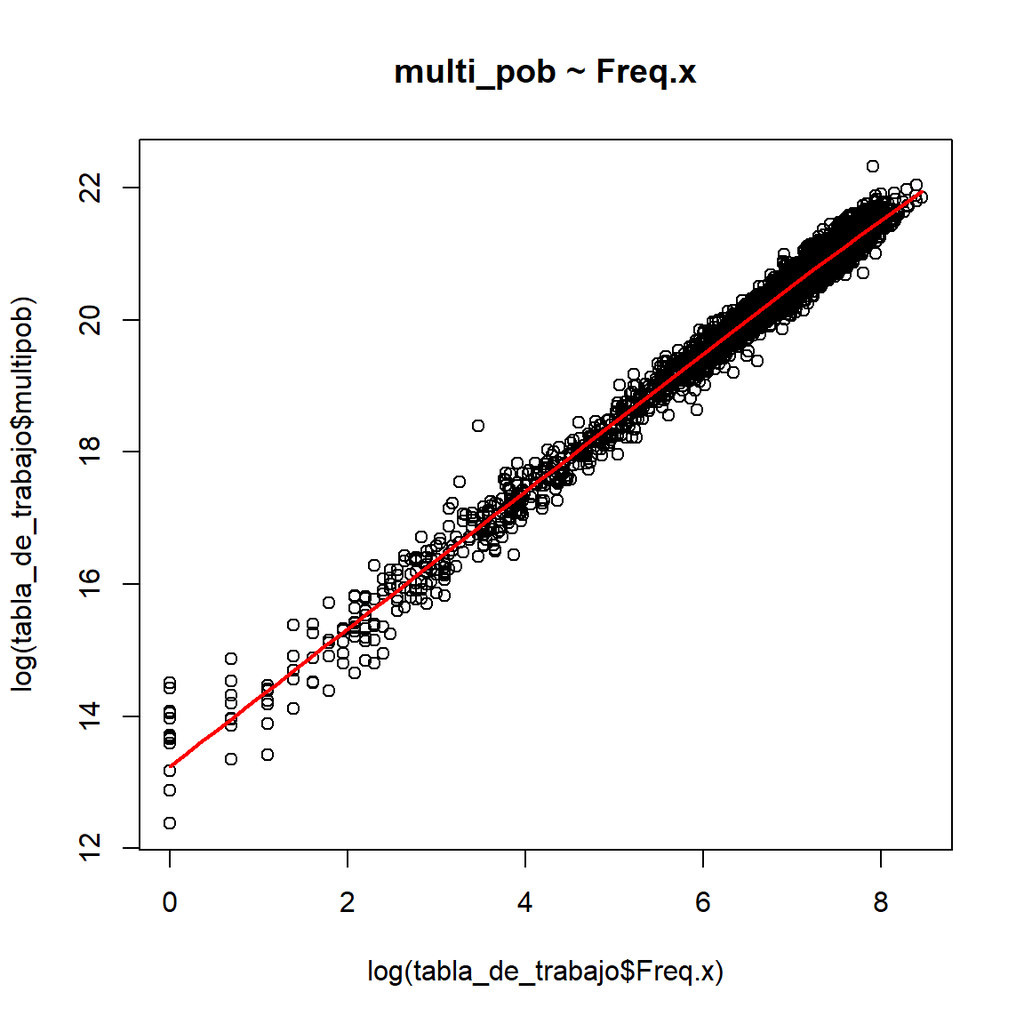

```r
scatter.smooth(x=log(tabla_de_trabajo$Freq.x), y=log(tabla_de_trabajo$multipob), lpars = list(col = "red", lwd = 2, lty = 1), main="multi_pob ~ Freq.x")
```

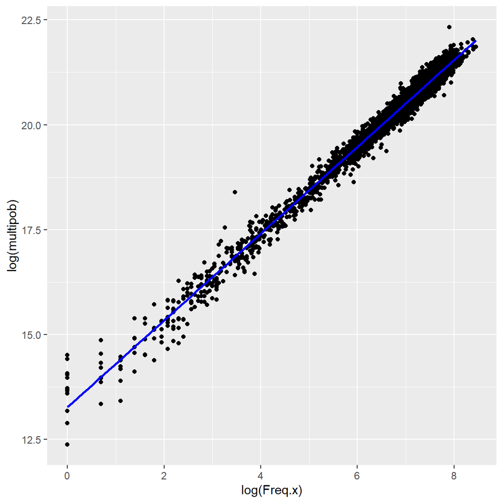

```r
ggplot(tabla_de_trabajo, aes(x = log(Freq.x) , y = log(multipob))) + geom_point() + stat_smooth(method=lm , color="blue",  level = 0.9, fill="green", se=TRUE)
```

### 5.1.2 Análisis de residuos

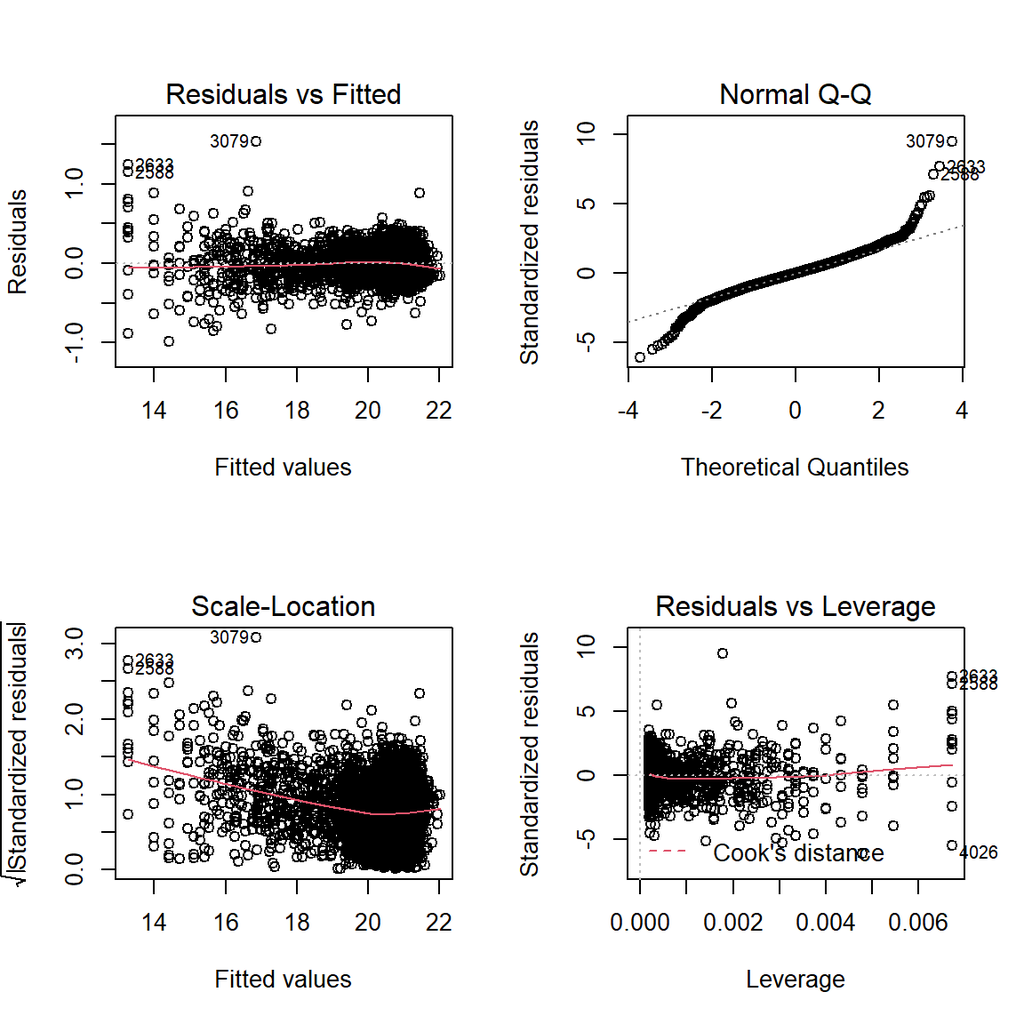

```r
par(mfrow = c (2,2))
plot(linearMod)
```

### 5.1.3 Modelo log-log

$$\hat Y = e^{\beta_0+\beta_1 ln{X}}$$

```r
linearMod <- lm( log(multipob)~log(Freq.x) , data=tabla_de_trabajo)
aa <- linearMod$coefficients[1]
bb <- linearMod$coefficients[2]
```

# 6 Aplicación la regresión a los valores de la variable a nivel de zona

Esta nueva variable se llamará: est_ing

```r
tabla_de_trabajo$est_ing <- exp(aa+bb*log(tabla_de_trabajo$Freq.x))
```

# 7 División del valor estimado entre la población total de la zona para obtener el ingreso medio por zona

$$Ingreso \_ Medio\_zona = est\_ing / (personas * p\_poblacional)$$

```r
tabla_de_trabajo$ing_medio_zona <- tabla_de_trabajo$est_ing /(tabla_de_trabajo$personas  * tabla_de_trabajo$p)
write_xlsx(tabla_de_trabajo, "tabla_de_trabajo_2.xlsx")
write.dbf(tabla_de_trabajo, "tabla_de_trabajo_2.dbf")
r3_100 <- tabla_de_trabajo[c(1:100),]
kbl(r3_100) %>%
  kable_styling(bootstrap_options = c("striped", "hover")) %>%
  kable_paper() %>%
  scroll_box(width = "100%", height = "300px")
```

| clave | código.x | Freq.x | personas | comuna | promedio_i | año | ingresos_expandidos | Freq.y | p | código.y | multipob | est_ing | ing_medio_zona |
| --- | --- | --- | --- | --- | --- | --- | --- | --- | --- | --- | --- | --- | --- |
| 10101011001 | 10101 | 320 | 245902 | Puerto Montt | 304409.6 | 2017 | 74854925754 | 584 | 0.0023749 | 10101 | 177775197.6 | 225812484 | 386665.2 |
| 10101011002 | 10101 | 1309 | 245902 | Puerto Montt | 304409.6 | 2017 | 74854925754 | 2941 | 0.0119600 | 10101 | 895268589.3 | 969027564 | 329489.1 |
| 10101021001 | 10101 | 1828 | 245902 | Puerto Montt | 304409.6 | 2017 | 74854925754 | 3953 | 0.0160755 | 10101 | 1203331089.2 | 1368684549 | 346239.5 |
| 10101021002 | 10101 | 581 | 245902 | Puerto Montt | 304409.6 | 2017 | 74854925754 | 1107 | 0.0045018 | 10101 | 336981410.5 | 418388755 | 377948.3 |
| 10101021003 | 10101 | 1050 | 245902 | Puerto Montt | 304409.6 | 2017 | 74854925754 | 2294 | 0.0093289 | 10101 | 698315587.8 | 771490596 | 336308.0 |
| 10101021004 | 10101 | 1457 | 245902 | Puerto Montt | 304409.6 | 2017 | 74854925754 | 3391 | 0.0137900 | 10101 | 1032252902.5 | 1082524004 | 319234.4 |
| 10101021005 | 10101 | 1165 | 245902 | Puerto Montt | 304409.6 | 2017 | 74854925754 | 2564 | 0.0104269 | 10101 | 780506175.8 | 859016955 | 335030.0 |
| 10101031001 | 10101 | 2012 | 245902 | Puerto Montt | 304409.6 | 2017 | 74854925754 | 4530 | 0.0184220 | 10101 | 1378975419.7 | 1511371232 | 333636.0 |
| 10101031002 | 10101 | 2166 | 245902 | Puerto Montt | 304409.6 | 2017 | 74854925754 | 4740 | 0.0192760 | 10101 | 1442901432.6 | 1631137384 | 344121.8 |
| 10101031003 | 10101 | 1663 | 245902 | Puerto Montt | 304409.6 | 2017 | 74854925754 | 4107 | 0.0167018 | 10101 | 1250210165.3 | 1241145581 | 302202.5 |
| 10101031004 | 10101 | 1172 | 245902 | Puerto Montt | 304409.6 | 2017 | 74854925754 | 2856 | 0.0116144 | 10101 | 869393774.6 | 864354445 | 302645.1 |
| 10101031005 | 10101 | 2657 | 245902 | Puerto Montt | 304409.6 | 2017 | 74854925754 | 5690 | 0.0231393 | 10101 | 1732090538.3 | 2014838451 | 354101.7 |
| 10101031006 | 10101 | 1233 | 245902 | Puerto Montt | 304409.6 | 2017 | 74854925754 | 2460 | 0.0100040 | 10101 | 748847578.9 | 910912070 | 370289.5 |
| 10101031007 | 10101 | 1038 | 245902 | Puerto Montt | 304409.6 | 2017 | 74854925754 | 2292 | 0.0093208 | 10101 | 697706768.7 | 762375593 | 332624.6 |
| 10101031008 | 10101 | 1616 | 245902 | Puerto Montt | 304409.6 | 2017 | 74854925754 | 3585 | 0.0145790 | 10101 | 1091308362.0 | 1204893190 | 336092.9 |
| 10101031009 | 10101 | 1995 | 245902 | Puerto Montt | 304409.6 | 2017 | 74854925754 | 4436 | 0.0180397 | 10101 | 1350360918.8 | 1498168966 | 337729.7 |
| 10101031010 | 10101 | 1531 | 245902 | Puerto Montt | 304409.6 | 2017 | 74854925754 | 3566 | 0.0145017 | 10101 | 1085524579.9 | 1139422061 | 319523.9 |
| 10101031011 | 10101 | 1232 | 245902 | Puerto Montt | 304409.6 | 2017 | 74854925754 | 2757 | 0.0112118 | 10101 | 839257225.7 | 910148187 | 330122.7 |
| 10101031012 | 10101 | 837 | 245902 | Puerto Montt | 304409.6 | 2017 | 74854925754 | 1849 | 0.0075193 | 10101 | 562853322.5 | 610266318 | 330052.1 |
| 10101031013 | 10101 | 1642 | 245902 | Puerto Montt | 304409.6 | 2017 | 74854925754 | 3945 | 0.0160430 | 10101 | 1200895812.6 | 1224943339 | 310505.3 |
| 10101031014 | 10101 | 1030 | 245902 | Puerto Montt | 304409.6 | 2017 | 74854925754 | 2265 | 0.0092110 | 10101 | 689487709.9 | 756300911 | 333907.7 |
| 10101031015 | 10101 | 873 | 245902 | Puerto Montt | 304409.6 | 2017 | 74854925754 | 1930 | 0.0078487 | 10101 | 587510498.9 | 637426237 | 330272.7 |
| 10101031016 | 10101 | 1285 | 245902 | Puerto Montt | 304409.6 | 2017 | 74854925754 | 3071 | 0.0124887 | 10101 | 934841835.3 | 950662583 | 309561.2 |
| 10101031017 | 10101 | 1457 | 245902 | Puerto Montt | 304409.6 | 2017 | 74854925754 | 3885 | 0.0157990 | 10101 | 1182631237.5 | 1082524004 | 278642.0 |
| 10101041001 | 10101 | 1843 | 245902 | Puerto Montt | 304409.6 | 2017 | 74854925754 | 4342 | 0.0176574 | 10101 | 1321746417.8 | 1380298976 | 317894.7 |
| 10101041002 | 10101 | 895 | 245902 | Puerto Montt | 304409.6 | 2017 | 74854925754 | 2169 | 0.0088206 | 10101 | 660264389.7 | 654042823 | 301541.2 |
| 10101041003 | 10101 | 2559 | 245902 | Puerto Montt | 304409.6 | 2017 | 74854925754 | 5202 | 0.0211548 | 10101 | 1583538660.8 | 1938046089 | 372557.9 |
| 10101051001 | 10101 | 1148 | 245902 | Puerto Montt | 304409.6 | 2017 | 74854925754 | 2463 | 0.0100162 | 10101 | 749760807.7 | 846059032 | 343507.5 |
| 10101051002 | 10101 | 814 | 245902 | Puerto Montt | 304409.6 | 2017 | 74854925754 | 1913 | 0.0077795 | 10101 | 582335536.0 | 592934824 | 309950.2 |
| 10101051003 | 10101 | 1329 | 245902 | Puerto Montt | 304409.6 | 2017 | 74854925754 | 3272 | 0.0133061 | 10101 | 996028161.9 | 984340471 | 300837.6 |

[output cut: 70 more lines]

## 7.1 Estadísticos

```r
ingresos <- readRDS("Ingresos_expandidos_urbano_17.rds")
kbl(ingresos) %>%
  kable_styling(bootstrap_options = c("striped", "hover")) %>%
  kable_paper() %>%
  scroll_box(width = "100%", height = "300px")
```

|  | código | personas | comuna | promedio_i | año | ingresos_expandidos |
| --- | --- | --- | --- | --- | --- | --- |
| 1 | 01101 | 191468 | Iquique | 375676.9 | 2017 | 71930106513 |
| 2 | 01107 | 108375 | Alto Hospicio | 311571.7 | 2017 | 33766585496 |
| 3 | 01401 | 15711 | Pozo Almonte | 316138.5 | 2017 | 4966851883 |
| 7 | 01405 | 9296 | Pica | 330061.1 | 2017 | 3068247619 |
| 8 | 02101 | 361873 | Antofagasta | 368221.4 | 2017 | 133249367039 |
| 9 | 02102 | 13467 | Mejillones | 369770.7 | 2017 | 4979702302 |
| 11 | 02104 | 13317 | Taltal | 383666.2 | 2017 | 5109282942 |
| 12 | 02201 | 165731 | Calama | 434325.1 | 2017 | 71981127235 |
| 14 | 02203 | 10996 | San Pedro de Atacama | 442861.0 | 2017 | 4869699464 |
| 15 | 02301 | 25186 | Tocopilla | 286187.2 | 2017 | 7207910819 |
| 16 | 02302 | 6457 | María Elena | 477748.0 | 2017 | 3084818966 |
| 17 | 03101 | 153937 | Copiapó | 343121.0 | 2017 | 52819016037 |
| 18 | 03102 | 17662 | Caldera | 318653.2 | 2017 | 5628052276 |
| 19 | 03103 | 14019 | Tierra Amarilla | 333194.9 | 2017 | 4671058718 |
| 20 | 03201 | 12219 | Chañaral | 286389.3 | 2017 | 3499391196 |
| 21 | 03202 | 13925 | Diego de Almagro | 351583.9 | 2017 | 4895805596 |
| 22 | 03301 | 51917 | Vallenar | 315981.5 | 2017 | 16404810756 |
| 24 | 03303 | 7041 | Freirina | 289049.9 | 2017 | 2035200054 |
| 25 | 03304 | 10149 | Huasco | 337414.8 | 2017 | 3424422750 |
| 26 | 04101 | 221054 | La Serena | 279340.1 | 2017 | 61749247282 |
| 27 | 04102 | 227730 | Coquimbo | 269078.6 | 2017 | 61277269093 |
| 28 | 04103 | 11044 | Andacollo | 258539.7 | 2017 | 2855312920 |
| 29 | 04104 | 4241 | La Higuera | 214257.0 | 2017 | 908664019 |
| 31 | 04106 | 27771 | Vicuña | 254177.0 | 2017 | 7058750373 |
| 32 | 04201 | 30848 | Illapel | 282139.3 | 2017 | 8703433491 |
| 33 | 04202 | 9093 | Canela | 233397.3 | 2017 | 2122281844 |
| 34 | 04203 | 21382 | Los Vilos | 285214.0 | 2017 | 6098444926 |
| 35 | 04204 | 29347 | Salamanca | 262056.9 | 2017 | 7690585032 |
| 36 | 04301 | 111272 | Ovalle | 280373.5 | 2017 | 31197719080 |
| 37 | 04302 | 13322 | Combarbalá | 234537.3 | 2017 | 3124505460 |

[output cut: 282 more lines]

### 7.1.1 Promedio

```r
t_de_c <- tabla_de_trabajo %>%
  group_by(código.y) %>%
  summarize(mean = mean(ing_medio_zona, na.rm = TRUE))
names(t_de_c)[1] <- "código"
estadisticos_finales <- merge( x = ingresos, y = t_de_c, by = "código", all.x = TRUE)
```

### 7.1.2 Desviación standard

```r
t_de_c_2 <- tabla_de_trabajo %>%
  group_by(código.y) %>%
  summarize(sd = sd(ing_medio_zona, na.rm = TRUE))
names(t_de_c_2)[1] <- "código"
estadisticos_finales <- merge( x = estadisticos_finales, y = t_de_c_2, by = "código", all.x = TRUE)
```

### 7.1.3 Mínimo

```r
t_de_c_3 <- tabla_de_trabajo %>%
  group_by(código.y) %>%
  summarize(min = min(ing_medio_zona, na.rm = TRUE))
names(t_de_c_3)[1] <- "código"
estadisticos_finales <- merge( x = estadisticos_finales, y = t_de_c_3, by = "código", all.x = TRUE)
```

### 7.1.4 Máximo

```r
t_de_c_4 <- tabla_de_trabajo %>%
  group_by(código.y) %>%
  summarize(max = max(ing_medio_zona, na.rm = TRUE))
names(t_de_c_4)[1] <- "código"
estadisticos_finales <- merge( x = estadisticos_finales, y = t_de_c_4, by = "código", all.x = TRUE)
```

### 7.1.5 Mediana

```r
t_de_c_5 <- tabla_de_trabajo %>%
  group_by(código.y) %>%
  summarize(median = median(ing_medio_zona, na.rm = TRUE))
names(t_de_c_5)[1] <- "código"
estadisticos_finales <- merge( x = estadisticos_finales, y = t_de_c_5, by = "código", all.x = TRUE)
kbl(estadisticos_finales) %>%
  kable_styling(bootstrap_options = c("striped", "hover")) %>%
  kable_paper() %>%
  scroll_box(width = "100%", height = "300px")
```

| código | personas | comuna | promedio_i | año | ingresos_expandidos | mean | sd | min | max | median |
| --- | --- | --- | --- | --- | --- | --- | --- | --- | --- | --- |
| 01101 | 191468 | Iquique | 375676.9 | 2017 | 71930106513 | 336932.5 | 30379.201 | 287239.14 | 404791.9 | 330193.5 |
| 01107 | 108375 | Alto Hospicio | 311571.7 | 2017 | 33766585496 | 287355.9 | 13224.968 | 268365.43 | 325896.6 | 284302.9 |
| 01401 | 15711 | Pozo Almonte | 316138.5 | 2017 | 4966851883 | 404223.4 | 217202.815 | 260413.30 | 654078.0 | 298178.9 |
| 01405 | 9296 | Pica | 330061.1 | 2017 | 3068247619 | 305865.5 | 19913.032 | 291784.88 | 319946.2 | 305865.5 |
| 02101 | 361873 | Antofagasta | 368221.4 | 2017 | 133249367039 | 316433.3 | 35863.939 | 263943.86 | 459458.1 | 306122.7 |
| 02102 | 13467 | Mejillones | 369770.7 | 2017 | 4979702302 | 439311.2 | 72542.396 | 377530.10 | 519188.7 | 421214.7 |
| 02104 | 13317 | Taltal | 383666.2 | 2017 | 5109282942 | 324585.5 | 39014.970 | 289770.48 | 379173.0 | 314699.3 |
| 02201 | 165731 | Calama | 434325.1 | 2017 | 71981127235 | 312175.4 | 47419.462 | 244061.27 | 553019.5 | 304505.4 |
| 02203 | 10996 | San Pedro de Atacama | 442861.0 | 2017 | 4869699464 | 377684.1 | 25754.958 | 359472.63 | 395895.6 | 377684.1 |
| 02301 | 25186 | Tocopilla | 286187.2 | 2017 | 7207910819 | 282459.8 | 67548.694 | 231307.27 | 476934.1 | 255506.8 |
| 02302 | 6457 | María Elena | 477748.0 | 2017 | 3084818966 | 364409.8 | 23849.594 | 344634.52 | 390895.8 | 357699.0 |
| 03101 | 153937 | Copiapó | 343121.0 | 2017 | 52819016037 | 294190.3 | 32048.528 | 246016.17 | 396376.8 | 287619.5 |
| 03102 | 17662 | Caldera | 318653.2 | 2017 | 5628052276 | 333036.6 | 38246.203 | 297260.93 | 396426.7 | 324567.0 |
| 03103 | 14019 | Tierra Amarilla | 333194.9 | 2017 | 4671058718 | 278189.4 | 92142.116 | 226469.17 | 415905.0 | 235191.7 |
| 03201 | 12219 | Chañaral | 286389.3 | 2017 | 3499391196 | 256025.0 | 67923.871 | 118767.14 | 324874.6 | 270558.5 |
| 03202 | 13925 | Diego de Almagro | 351583.9 | 2017 | 4895805596 | 315058.6 | 54526.666 | 250393.26 | 401415.5 | 303361.4 |
| 03301 | 51917 | Vallenar | 315981.5 | 2017 | 16404810756 | 278400.9 | 39223.506 | 234014.36 | 343600.5 | 259078.4 |
| 03303 | 7041 | Freirina | 289049.9 | 2017 | 2035200054 | 390884.2 | 234843.652 | 241720.41 | 661588.9 | 269343.2 |
| 03304 | 10149 | Huasco | 337414.8 | 2017 | 3424422750 | 311636.7 | 40859.835 | 272211.41 | 379345.8 | 298448.7 |
| 04101 | 221054 | La Serena | 279340.1 | 2017 | 61749247282 | 282492.2 | 23765.052 | 240651.67 | 386556.6 | 280354.4 |
| 04102 | 227730 | Coquimbo | 269078.6 | 2017 | 61277269093 | 286925.6 | 20722.703 | 246807.05 | 338325.4 | 286053.3 |
| 04103 | 11044 | Andacollo | 258539.7 | 2017 | 2855312920 | 256551.7 | 4914.570 | 252752.69 | 262102.1 | 254800.4 |
| 04104 | 4241 | La Higuera | 214257.0 | 2017 | 908664019 | 231254.3 | 16320.050 | 219714.33 | 242794.4 | 231254.3 |
| 04106 | 27771 | Vicuña | 254177.0 | 2017 | 7058750373 | 287777.1 | 43439.033 | 257521.05 | 382890.6 | 267819.2 |
| 04201 | 30848 | Illapel | 282139.3 | 2017 | 8703433491 | 287112.2 | 33893.073 | 257095.70 | 354536.2 | 274326.4 |
| 04202 | 9093 | Canela | 233397.3 | 2017 | 2122281844 | 234142.4 | 76111.371 | 180323.54 | 287961.3 | 234142.4 |
| 04203 | 21382 | Los Vilos | 285214.0 | 2017 | 6098444926 | 338040.5 | 46966.082 | 297974.03 | 438023.5 | 335335.6 |
| 04204 | 29347 | Salamanca | 262056.9 | 2017 | 7690585032 | 304302.8 | 41409.818 | 242849.26 | 369610.5 | 297046.3 |
| 04301 | 111272 | Ovalle | 280373.5 | 2017 | 31197719080 | 284137.0 | 50989.002 | 60175.86 | 365477.2 | 289736.0 |
| 04302 | 13322 | Combarbalá | 234537.3 | 2017 | 3124505460 | 297031.7 | 21921.280 | 273496.12 | 316867.9 | 300731.2 |

[output cut: 282 more lines]

```r
write_xlsx(estadisticos_finales, "estadisticos_finales.xlsx")
write.dbf(estadisticos_finales, "estadisticos_finales.dbf")
```